# Introduction to descriptr

## Introduction

Descriptive statistics are used to summarize data. It enables us to present the data in a more meaningful way and to discern any patterns existing in the data. They can be useful for two purposes:

- provide basic information about variables in a data set
- highlight potential relationships between variables

This document introduces you to a basic set of functions that describe data. There is a second vignette which provides details about functions which help visualize statistical distributions.

## Data

We have modified the `mtcars` data to create a new data set `mtcarz`. The only difference between the two data sets is related to the variable types.

```r
str(mtcarz)
```

```
## 'data.frame':    32 obs. of  11 variables:
##  $ mpg : num  21 21 22.8 21.4 18.7 18.1 14.3 24.4 22.8 19.2 ...
##  $ cyl : Factor w/ 3 levels "4","6","8": 2 2 1 2 3 2 3 1 1 2 ...
##  $ disp: num  160 160 108 258 360 ...
##  $ hp  : num  110 110 93 110 175 105 245 62 95 123 ...
##  $ drat: num  3.9 3.9 3.85 3.08 3.15 2.76 3.21 3.69 3.92 3.92 ...
##  $ wt  : num  2.62 2.88 2.32 3.21 3.44 ...
##  $ qsec: num  16.5 17 18.6 19.4 17 ...
##  $ vs  : Factor w/ 2 levels "0","1": 1 1 2 2 1 2 1 2 2 2 ...
##  $ am  : Factor w/ 2 levels "0","1": 2 2 2 1 1 1 1 1 1 1 ...
##  $ gear: Factor w/ 3 levels "3","4","5": 2 2 2 1 1 1 1 2 2 2 ...
##  $ carb: Factor w/ 6 levels "1","2","3","4",..: 4 4 1 1 2 1 4 2 2 4 ...
```

## Data Screening

The `ds_screener()` function will screen a data set and return the following: - Column/Variable Names - Data Type - Levels (in case of categorical data) - Number of missing observations - % of missing observations

```r
ds_screener(mtcarz)
```

```
## -----------------------------------------------------------------------
## |  Column Name  |  Data Type  |  Levels   |  Missing  |  Missing (%)  |
## -----------------------------------------------------------------------
## |      mpg      |   numeric   |    NA     |     0     |       0       |
## |      cyl      |   factor    |   4 6 8   |     0     |       0       |
## |     disp      |   numeric   |    NA     |     0     |       0       |
## |      hp       |   numeric   |    NA     |     0     |       0       |
## |     drat      |   numeric   |    NA     |     0     |       0       |
## |      wt       |   numeric   |    NA     |     0     |       0       |
## |     qsec      |   numeric   |    NA     |     0     |       0       |
## |      vs       |   factor    |    0 1    |     0     |       0       |
## |      am       |   factor    |    0 1    |     0     |       0       |
## |     gear      |   factor    |   3 4 5   |     0     |       0       |
## |     carb      |   factor    |1 2 3 4 6 8|     0     |       0       |
## -----------------------------------------------------------------------
##
##  Overall Missing Values           0
##  Percentage of Missing Values     0 %
##  Rows with Missing Values         0
##  Columns With Missing Values      0
```

## Summary Statistics

The `ds_summary_stats` function returns a comprehensive set of statistics for **continuous** data.

```r
ds_summary_stats(mtcarz, mpg)
```

```
##                         Univariate Analysis
##
##  N                       32.00      Variance                36.32
##  Missing                  0.00      Std Deviation            6.03
##  Mean                    20.09      Range                   23.50
##  Median                  19.20      Interquartile Range      7.38
##  Mode                    10.40      Uncorrected SS       14042.31
##  Trimmed Mean            19.95      Corrected SS          1126.05
##  Skewness                 0.67      Coeff Variation         30.00
##  Kurtosis                -0.02      Std Error Mean           1.07
##
##                               Quantiles
##
##               Quantile                            Value
##
##              Max                                  33.90
##              99%                                  33.44
##              95%                                  31.30
##              90%                                  30.09
##              Q3                                   22.80
##              Median                               19.20
##              Q1                                   15.43
##              10%                                  14.34
##              5%                                   12.00
##              1%                                   10.40
##              Min                                  10.40
##
##                             Extreme Values
##
##                 Low                                High
##
##   Obs                        Value       Obs                        Value
##   15                         10.4        20                         33.9
##   16                         10.4        18                         32.4
##   24                         13.3        19                         30.4
##    7                         14.3        28                         30.4
##   17                         14.7        26                         27.3
```

## Cross Tabulation

The `ds_cross_table()` function creates two way tables of categorical variables.

```r
ds_cross_table(mtcarz, cyl, gear)
```

```
##     Cell Contents
##  |---------------|
##  |     Frequency |
##  |       Percent |
##  |       Row Pct |
##  |       Col Pct |
##  |---------------|
##
##  Total Observations:  32
##
## ----------------------------------------------------------------------------
## |              |                           gear                            |
## ----------------------------------------------------------------------------
## |          cyl |            3 |            4 |            5 |    Row Total |
## ----------------------------------------------------------------------------
## |            4 |            1 |            8 |            2 |           11 |
## |              |        0.031 |         0.25 |        0.062 |              |
## |              |         0.09 |         0.73 |         0.18 |         0.34 |
## |              |         0.07 |         0.67 |          0.4 |              |
## ----------------------------------------------------------------------------
## |            6 |            2 |            4 |            1 |            7 |
## |              |        0.062 |        0.125 |        0.031 |              |
## |              |         0.29 |         0.57 |         0.14 |         0.22 |
## |              |         0.13 |         0.33 |          0.2 |              |
## ----------------------------------------------------------------------------
## |            8 |           12 |            0 |            2 |           14 |
## |              |        0.375 |            0 |        0.062 |              |
## |              |         0.86 |            0 |         0.14 |         0.44 |
## |              |          0.8 |            0 |          0.4 |              |
## ----------------------------------------------------------------------------
## | Column Total |           15 |           12 |            5 |           32 |
## |              |        0.468 |        0.375 |        0.155 |              |
## ----------------------------------------------------------------------------
```

`ds_twoway_table()` will return a tibble.

```r
ds_twoway_table(mtcarz, cyl, gear)
```

```
## # A tibble: 8 x 6
##   cyl   gear  count percent row_percent col_percent
##   <fct> <fct> <int>   <dbl>       <dbl>       <dbl>
## 1 4     3         1  0.0312      0.0909      0.0667
## 2 4     4         8  0.250       0.727       0.667
## 3 4     5         2  0.0625      0.182       0.400
## 4 6     3         2  0.0625      0.286       0.133
## 5 6     4         4  0.125       0.571       0.333
## 6 6     5         1  0.0312      0.143       0.200
## 7 8     3        12  0.375       0.857       0.800
## 8 8     5         2  0.0625      0.143       0.400
```

A plot method has been defined which will generate:

### Grouped Bar Plots

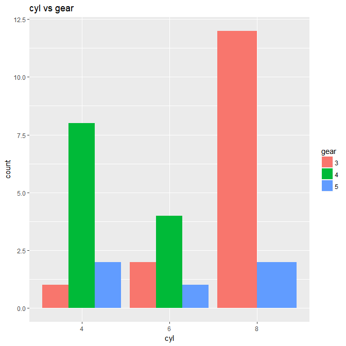

```r
k <- ds_cross_table(mtcarz, cyl, gear)
plot(k)
```

### Stacked Bar Plots

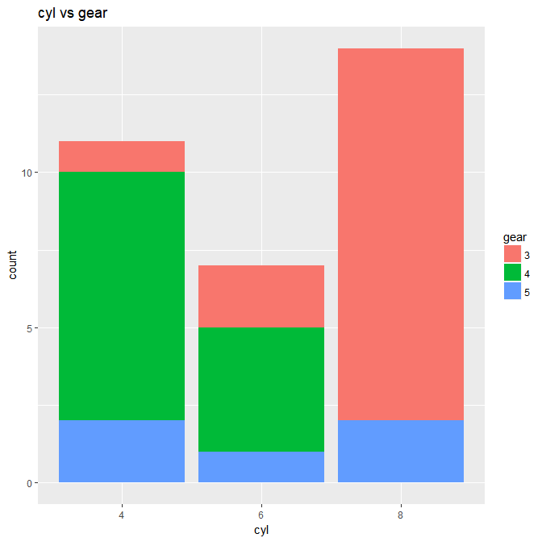

```r
k <- ds_cross_table(mtcarz, cyl, gear)
plot(k, stacked = TRUE)
```

### Proportional Bar Plots

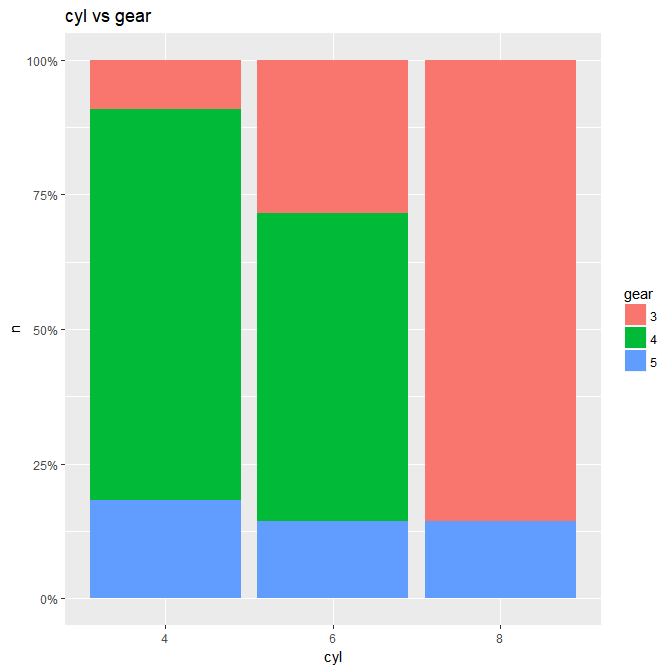

```r
k <- ds_cross_table(mtcarz, cyl, gear)
plot(k, proportional = TRUE)
```

## Frequency Table (Categorical Data)

The `ds_freq_table()` function creates frequency tables for categorical variables.

```r
ds_freq_table(mtcarz, cyl)
```

```
##                              Variable: cyl
## -----------------------------------------------------------------------
## Levels     Frequency    Cum Frequency       Percent        Cum Percent
## -----------------------------------------------------------------------
##    4          11             11              34.38            34.38
## -----------------------------------------------------------------------
##    6           7             18              21.88            56.25
## -----------------------------------------------------------------------
##    8          14             32              43.75             100
## -----------------------------------------------------------------------
##  Total        32              -             100.00              -
## -----------------------------------------------------------------------
```

### Bar Plot

A barplot method has been defined.

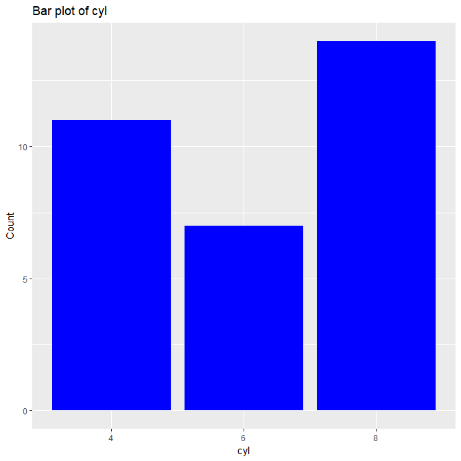

```r
k <- ds_freq_table(mtcarz, cyl)
plot(k)
```

## Frequency Table (Continuous Data)

The `ds_freq_cont` function creates frequency tables for continuous variables. The default number of intervals is 5.

```r
ds_freq_cont(mtcarz, mpg, 4)
```

```
##                                 Variable: mpg
## |---------------------------------------------------------------------------|
## |      Bins       | Frequency | Cum Frequency |   Percent    | Cum Percent  |
## |---------------------------------------------------------------------------|
## |  10.4  -  16.3  |    10     |      10       |    31.25     |    31.25     |
## |---------------------------------------------------------------------------|
## |  16.3  -  22.1  |    13     |      23       |    40.62     |    71.88     |
## |---------------------------------------------------------------------------|
## |  22.1  -   28   |     5     |      28       |    15.62     |     87.5     |
## |---------------------------------------------------------------------------|
## |   28   -  33.9  |     4     |      32       |     12.5     |     100      |
## |---------------------------------------------------------------------------|
## |      Total      |    32     |       -       |    100.00    |      -       |
## |---------------------------------------------------------------------------|
```

### Histogram

A `hist` method has been defined.

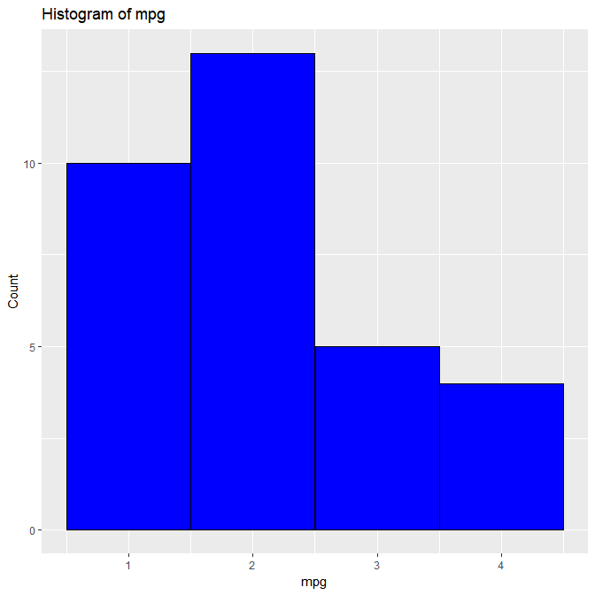

```r
k <- ds_freq_cont(mtcarz, mpg, 4)
plot(k)
```

## Group Summary

The `ds_group_summary()` function returns descriptive statistics of a continuous variable for the different levels of a categorical variable.

```r
k <- ds_group_summary(mtcarz, cyl, mpg)
k
```

```
##                                        mpg by cyl
## -----------------------------------------------------------------------------------------
## |     Statistic/Levels|                    4|                    6|                    8|
## -----------------------------------------------------------------------------------------
## |                  Obs|                   11|                    7|                   14|
## |              Minimum|                 21.4|                 17.8|                 10.4|
## |              Maximum|                 33.9|                 21.4|                 19.2|
## |                 Mean|                26.66|                19.74|                 15.1|
## |               Median|                   26|                 19.7|                 15.2|
## |                 Mode|                 22.8|                   21|                 10.4|
## |       Std. Deviation|                 4.51|                 1.45|                 2.56|
## |             Variance|                20.34|                 2.11|                 6.55|
## |             Skewness|                 0.35|                -0.26|                -0.46|
## |             Kurtosis|                -1.43|                -1.83|                 0.33|
## |       Uncorrected SS|              8023.83|              2741.14|              3277.34|
## |         Corrected SS|               203.39|                12.68|                 85.2|
## |      Coeff Variation|                16.91|                 7.36|                16.95|
## |      Std. Error Mean|                 1.36|                 0.55|                 0.68|
## |                Range|                 12.5|                  3.6|                  8.8|
## |  Interquartile Range|                  7.6|                 2.35|                 1.85|
## -----------------------------------------------------------------------------------------
```

`ds_group_summary()` returns a tibble which can be used for further analysis.

```r
k$tidy_stats
```

```
## # A tibble: 3 x 15
##   cyl   length   min   max  mean median  mode    sd variance skewness
##   <fct>  <int> <dbl> <dbl> <dbl>  <dbl> <dbl> <dbl>    <dbl>    <dbl>
## 1 4         11  21.4  33.9  26.7   26.0  22.8  4.51    20.3     0.348
## 2 6          7  17.8  21.4  19.7   19.7  21.0  1.45     2.11   -0.259
## 3 8         14  10.4  19.2  15.1   15.2  10.4  2.56     6.55   -0.456
## # ... with 5 more variables: kurtosis <dbl>, coeff_var <dbl>,
## #   std_error <dbl>, range <dbl>, iqr <dbl>
```

### Box Plot

A `boxplot()` method has been defined.

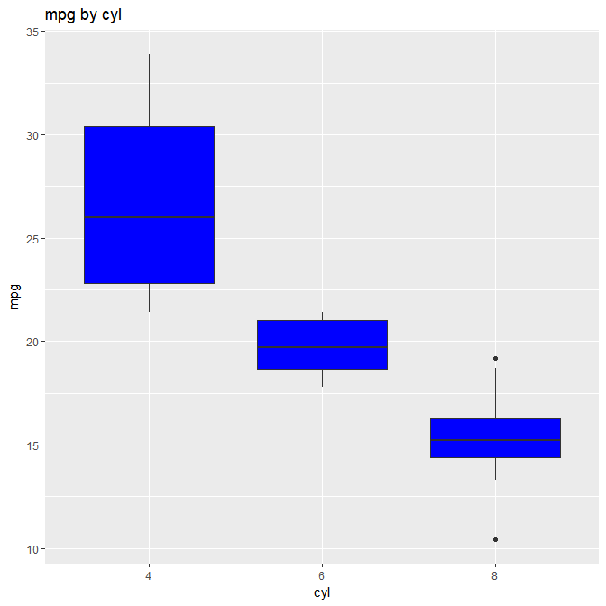

```r
k <- ds_group_summary(mtcarz, cyl, mpg)
plot(k)
```

## Multiple Variable Statistics

The `ds_multi_stats()` function generates summary/descriptive statistics for variables in a data frame/tibble.

```r
ds_multi_stats(mtcarz, mpg, disp, hp)
```

```
## # A tibble: 3 x 16
##   vars    min   max  mean t_mean median  mode range variance  stdev  skew
##   <chr> <dbl> <dbl> <dbl>  <dbl>  <dbl> <dbl> <dbl>    <dbl>  <dbl> <dbl>
## 1 disp   71.1 472   231    228    196   276   401    15361   124    0.420
## 2 hp     52.0 335   147    144    123   110   283     4701    68.6  0.799
## 3 mpg    10.4  33.9  20.1   20.0   19.2  10.4  23.5     36.3   6.03 0.672
## # ... with 5 more variables: kurtosis <dbl>, coeff_var <dbl>, q1 <dbl>,
## #   q3 <dbl>, iqrange <dbl>
```

## Multiple One Way Tables

The `ds_oway_tables()` function creates multiple one way tables by creating a frequency table for each categorical variable in a data frame.

```r
ds_oway_tables(mtcarz)
```

```
##                              Variable: cyl
## -----------------------------------------------------------------------
## Levels     Frequency    Cum Frequency       Percent        Cum Percent
## -----------------------------------------------------------------------
##    4          11             11              34.38            34.38
## -----------------------------------------------------------------------
##    6           7             18              21.88            56.25
## -----------------------------------------------------------------------
##    8          14             32              43.75             100
## -----------------------------------------------------------------------
##  Total        32              -             100.00              -
## -----------------------------------------------------------------------
##
##                              Variable: vs
## -----------------------------------------------------------------------
## Levels     Frequency    Cum Frequency       Percent        Cum Percent
## -----------------------------------------------------------------------
##    0          18             18              56.25            56.25
## -----------------------------------------------------------------------
##    1          14             32              43.75             100
## -----------------------------------------------------------------------
##  Total        32              -             100.00              -
## -----------------------------------------------------------------------
##
##                              Variable: am
## -----------------------------------------------------------------------
## Levels     Frequency    Cum Frequency       Percent        Cum Percent
## -----------------------------------------------------------------------
##    0          19             19              59.38            59.38
## -----------------------------------------------------------------------
##    1          13             32              40.62             100
## -----------------------------------------------------------------------
##  Total        32              -             100.00              -
## -----------------------------------------------------------------------
##
##                             Variable: gear
## -----------------------------------------------------------------------
## Levels     Frequency    Cum Frequency       Percent        Cum Percent
## -----------------------------------------------------------------------
##    3          15             15              46.88            46.88
```

[output cut: 11 more lines]

```
## -----------------------------------------------------------------------
##    1           7              7              21.88            21.88
## -----------------------------------------------------------------------
##    2          10             17              31.25            53.12
## -----------------------------------------------------------------------
##    3           3             20              9.38             62.5
## -----------------------------------------------------------------------
##    4          10             30              31.25            93.75
## -----------------------------------------------------------------------
##    6           1             31              3.12             96.88
## -----------------------------------------------------------------------
##    8           1             32              3.12              100
## -----------------------------------------------------------------------
##  Total        32              -             100.00              -
## -----------------------------------------------------------------------
```

## Multiple Two Way Tables

The `ds_tway_tables()` function creates multiple two way tables by creating a cross table for each unique pair of categorical variables in a data frame.

```r
ds_tway_tables(mtcarz)
```

```
##     Cell Contents
##  |---------------|
##  |     Frequency |
##  |       Percent |
##  |       Row Pct |
##  |       Col Pct |
##  |---------------|
##
##  Total Observations:  32
##
##                          cyl vs vs
## -------------------------------------------------------------
## |              |                     vs                     |
## -------------------------------------------------------------
## |          cyl |            0 |            1 |    Row Total |
## -------------------------------------------------------------
## |            4 |            1 |           10 |           11 |
## |              |        0.031 |        0.312 |              |
## |              |         0.09 |         0.91 |         0.34 |
## |              |         0.06 |         0.71 |              |
## -------------------------------------------------------------
## |            6 |            3 |            4 |            7 |
## |              |        0.094 |        0.125 |              |
## |              |         0.43 |         0.57 |         0.22 |
## |              |         0.17 |         0.29 |              |
## -------------------------------------------------------------
## |            8 |           14 |            0 |           14 |
## |              |        0.438 |            0 |              |
## |              |            1 |            0 |         0.44 |
## |              |         0.78 |            0 |              |
## -------------------------------------------------------------
## | Column Total |           18 |           14 |           32 |
## |              |        0.563 |        0.437 |              |
## -------------------------------------------------------------
##
##
##                          cyl vs am
## -------------------------------------------------------------
## |              |                     am                     |
## -------------------------------------------------------------
```

[output cut: 188 more lines]

```
## |              |         0.43 |          0.4 |            1 |          0.5 |            0 |            0 |              |
## -------------------------------------------------------------------------------------------------------------------------
## |            4 |            4 |            4 |            0 |            4 |            0 |            0 |           12 |
## |              |        0.125 |        0.125 |            0 |        0.125 |            0 |            0 |              |
## |              |         0.33 |         0.33 |            0 |         0.33 |            0 |            0 |         0.38 |
## |              |         0.57 |          0.4 |            0 |          0.4 |            0 |            0 |              |
## -------------------------------------------------------------------------------------------------------------------------
## |            5 |            0 |            2 |            0 |            1 |            1 |            1 |            5 |
## |              |            0 |        0.062 |            0 |        0.031 |        0.031 |        0.031 |              |
## |              |            0 |          0.4 |            0 |          0.2 |          0.2 |          0.2 |         0.16 |
## |              |            0 |          0.2 |            0 |          0.1 |            1 |            1 |              |
## -------------------------------------------------------------------------------------------------------------------------
## | Column Total |            7 |           10 |            3 |           10 |            1 |            1 |           32 |
## |              |        0.219 |        0.312 |        0.094 |        0.312 |        0.031 |        0.031 |              |
## -------------------------------------------------------------------------------------------------------------------------
```